# Risk Factor Analysis

## Outcome Variable

**Outcome Variable:** pers_wast

## Predictor Variables

**Intervention Variable:** brthmon

**Adjustment Set:**

unadjusted

## Stratifying Variables

The analysis was stratified on these variable(s):

- agecat
- studyid
- country

## Data Summary

| agecat | studyid | country | brthmon | pers_wast | n_cell | n | outcome_variable |
| --- | --- | --- | --- | --- | --- | --- | --- |
| 0-24 months | ki0047075b-MAL-ED | BANGLADESH | 1 | 0 | 20 | 248 | pers_wast |
| 0-24 months | ki0047075b-MAL-ED | BANGLADESH | 1 | 1 | 0 | 248 | pers_wast |
| 0-24 months | ki0047075b-MAL-ED | BANGLADESH | 2 | 0 | 20 | 248 | pers_wast |
| 0-24 months | ki0047075b-MAL-ED | BANGLADESH | 2 | 1 | 1 | 248 | pers_wast |
| 0-24 months | ki0047075b-MAL-ED | BANGLADESH | 3 | 0 | 22 | 248 | pers_wast |
| 0-24 months | ki0047075b-MAL-ED | BANGLADESH | 3 | 1 | 1 | 248 | pers_wast |
| 0-24 months | ki0047075b-MAL-ED | BANGLADESH | 4 | 0 | 21 | 248 | pers_wast |
| 0-24 months | ki0047075b-MAL-ED | BANGLADESH | 4 | 1 | 1 | 248 | pers_wast |
| 0-24 months | ki0047075b-MAL-ED | BANGLADESH | 5 | 0 | 19 | 248 | pers_wast |
| 0-24 months | ki0047075b-MAL-ED | BANGLADESH | 5 | 1 | 2 | 248 | pers_wast |
| 0-24 months | ki0047075b-MAL-ED | BANGLADESH | 6 | 0 | 9 | 248 | pers_wast |
| 0-24 months | ki0047075b-MAL-ED | BANGLADESH | 6 | 1 | 1 | 248 | pers_wast |
| 0-24 months | ki0047075b-MAL-ED | BANGLADESH | 7 | 0 | 17 | 248 | pers_wast |
| 0-24 months | ki0047075b-MAL-ED | BANGLADESH | 7 | 1 | 1 | 248 | pers_wast |
| 0-24 months | ki0047075b-MAL-ED | BANGLADESH | 8 | 0 | 25 | 248 | pers_wast |
| 0-24 months | ki0047075b-MAL-ED | BANGLADESH | 8 | 1 | 0 | 248 | pers_wast |
| 0-24 months | ki0047075b-MAL-ED | BANGLADESH | 9 | 0 | 20 | 248 | pers_wast |
| 0-24 months | ki0047075b-MAL-ED | BANGLADESH | 9 | 1 | 2 | 248 | pers_wast |
| 0-24 months | ki0047075b-MAL-ED | BANGLADESH | 10 | 0 | 20 | 248 | pers_wast |
| 0-24 months | ki0047075b-MAL-ED | BANGLADESH | 10 | 1 | 2 | 248 | pers_wast |
| 0-24 months | ki0047075b-MAL-ED | BANGLADESH | 11 | 0 | 15 | 248 | pers_wast |
| 0-24 months | ki0047075b-MAL-ED | BANGLADESH | 11 | 1 | 1 | 248 | pers_wast |
| 0-24 months | ki0047075b-MAL-ED | BANGLADESH | 12 | 0 | 27 | 248 | pers_wast |
| 0-24 months | ki0047075b-MAL-ED | BANGLADESH | 12 | 1 | 1 | 248 | pers_wast |
| 0-24 months | ki0047075b-MAL-ED | BRAZIL | 1 | 0 | 15 | 218 | pers_wast |
| 0-24 months | ki0047075b-MAL-ED | BRAZIL | 1 | 1 | 0 | 218 | pers_wast |
| 0-24 months | ki0047075b-MAL-ED | BRAZIL | 2 | 0 | 25 | 218 | pers_wast |
| 0-24 months | ki0047075b-MAL-ED | BRAZIL | 2 | 1 | 0 | 218 | pers_wast |
| 0-24 months | ki0047075b-MAL-ED | BRAZIL | 3 | 0 | 16 | 218 | pers_wast |
| 0-24 months | ki0047075b-MAL-ED | BRAZIL | 3 | 1 | 0 | 218 | pers_wast |

[output cut: 1770 more lines]

The following strata were considered:

- agecat: 0-24 months, studyid: ki0047075b-MAL-ED, country: BANGLADESH
- agecat: 0-24 months, studyid: ki0047075b-MAL-ED, country: BRAZIL
- agecat: 0-24 months, studyid: ki0047075b-MAL-ED, country: INDIA
- agecat: 0-24 months, studyid: ki0047075b-MAL-ED, country: NEPAL
- agecat: 0-24 months, studyid: ki0047075b-MAL-ED, country: PERU
- agecat: 0-24 months, studyid: ki0047075b-MAL-ED, country: SOUTH AFRICA
- agecat: 0-24 months, studyid: ki0047075b-MAL-ED, country: TANZANIA, UNITED REPUBLIC OF
- agecat: 0-24 months, studyid: ki1000108-CMC-V-BCS-2002, country: INDIA
- agecat: 0-24 months, studyid: ki1000108-IRC, country: INDIA
- agecat: 0-24 months, studyid: ki1000109-EE, country: PAKISTAN
- agecat: 0-24 months, studyid: ki1000109-ResPak, country: PAKISTAN
- agecat: 0-24 months, studyid: ki1000304b-SAS-CompFeed, country: INDIA
- agecat: 0-24 months, studyid: ki1000304b-SAS-FoodSuppl, country: INDIA
- agecat: 0-24 months, studyid: ki1017093-NIH-Birth, country: BANGLADESH
- agecat: 0-24 months, studyid: ki1017093b-PROVIDE, country: BANGLADESH
- agecat: 0-24 months, studyid: ki1066203-TanzaniaChild2, country: TANZANIA, UNITED REPUBLIC OF
- agecat: 0-24 months, studyid: ki1101329-Keneba, country: GAMBIA
- agecat: 0-24 months, studyid: ki1112895-Guatemala BSC, country: GUATEMALA
- agecat: 0-24 months, studyid: ki1112895-iLiNS-Zinc, country: BURKINA FASO
- agecat: 0-24 months, studyid: ki1113344-GMS-Nepal, country: NEPAL
- agecat: 0-24 months, studyid: ki1114097-CMIN, country: BANGLADESH
- agecat: 0-24 months, studyid: ki1114097-CONTENT, country: PERU
- agecat: 0-24 months, studyid: ki1119695-PROBIT, country: BELARUS
- agecat: 0-24 months, studyid: ki1126311-ZVITAMBO, country: ZIMBABWE
- agecat: 0-24 months, studyid: ki1148112-LCNI-5, country: MALAWI
- agecat: 0-24 months, studyid: kiGH5241-JiVitA-3, country: BANGLADESH
- agecat: 0-24 months, studyid: kiGH5241-JiVitA-4, country: BANGLADESH
- agecat: 0-6 months, studyid: ki0047075b-MAL-ED, country: BANGLADESH
- agecat: 0-6 months, studyid: ki0047075b-MAL-ED, country: BRAZIL
- agecat: 0-6 months, studyid: ki0047075b-MAL-ED, country: INDIA
- agecat: 0-6 months, studyid: ki0047075b-MAL-ED, country: NEPAL
- agecat: 0-6 months, studyid: ki0047075b-MAL-ED, country: PERU
- agecat: 0-6 months, studyid: ki0047075b-MAL-ED, country: SOUTH AFRICA
- agecat: 0-6 months, studyid: ki0047075b-MAL-ED, country: TANZANIA, UNITED REPUBLIC OF
- agecat: 0-6 months, studyid: ki1000108-CMC-V-BCS-2002, country: INDIA
- agecat: 0-6 months, studyid: ki1000108-IRC, country: INDIA
- agecat: 0-6 months, studyid: ki1000109-EE, country: PAKISTAN
- agecat: 0-6 months, studyid: ki1000109-ResPak, country: PAKISTAN
- agecat: 0-6 months, studyid: ki1017093-NIH-Birth, country: BANGLADESH
- agecat: 0-6 months, studyid: ki1017093b-PROVIDE, country: BANGLADESH
- agecat: 0-6 months, studyid: ki1066203-TanzaniaChild2, country: TANZANIA, UNITED REPUBLIC OF
- agecat: 0-6 months, studyid: ki1101329-Keneba, country: GAMBIA
- agecat: 0-6 months, studyid: ki1113344-GMS-Nepal, country: NEPAL
- agecat: 0-6 months, studyid: ki1114097-CMIN, country: BANGLADESH
- agecat: 0-6 months, studyid: ki1114097-CONTENT, country: PERU
- agecat: 0-6 months, studyid: ki1119695-PROBIT, country: BELARUS
- agecat: 0-6 months, studyid: ki1126311-ZVITAMBO, country: ZIMBABWE
- agecat: 0-6 months, studyid: kiGH5241-JiVitA-3, country: BANGLADESH
- agecat: 6-24 months, studyid: ki0047075b-MAL-ED, country: BANGLADESH
- agecat: 6-24 months, studyid: ki0047075b-MAL-ED, country: BRAZIL
- agecat: 6-24 months, studyid: ki0047075b-MAL-ED, country: INDIA
- agecat: 6-24 months, studyid: ki0047075b-MAL-ED, country: NEPAL
- agecat: 6-24 months, studyid: ki0047075b-MAL-ED, country: PERU
- agecat: 6-24 months, studyid: ki0047075b-MAL-ED, country: SOUTH AFRICA
- agecat: 6-24 months, studyid: ki0047075b-MAL-ED, country: TANZANIA, UNITED REPUBLIC OF
- agecat: 6-24 months, studyid: ki1000108-CMC-V-BCS-2002, country: INDIA
- agecat: 6-24 months, studyid: ki1000108-IRC, country: INDIA
- agecat: 6-24 months, studyid: ki1000109-EE, country: PAKISTAN
- agecat: 6-24 months, studyid: ki1000109-ResPak, country: PAKISTAN
- agecat: 6-24 months, studyid: ki1000304b-SAS-CompFeed, country: INDIA
- agecat: 6-24 months, studyid: ki1000304b-SAS-FoodSuppl, country: INDIA
- agecat: 6-24 months, studyid: ki1017093-NIH-Birth, country: BANGLADESH
- agecat: 6-24 months, studyid: ki1017093b-PROVIDE, country: BANGLADESH
- agecat: 6-24 months, studyid: ki1066203-TanzaniaChild2, country: TANZANIA, UNITED REPUBLIC OF
- agecat: 6-24 months, studyid: ki1101329-Keneba, country: GAMBIA
- agecat: 6-24 months, studyid: ki1112895-Guatemala BSC, country: GUATEMALA
- agecat: 6-24 months, studyid: ki1112895-iLiNS-Zinc, country: BURKINA FASO
- agecat: 6-24 months, studyid: ki1113344-GMS-Nepal, country: NEPAL
- agecat: 6-24 months, studyid: ki1114097-CMIN, country: BANGLADESH
- agecat: 6-24 months, studyid: ki1114097-CONTENT, country: PERU
- agecat: 6-24 months, studyid: ki1119695-PROBIT, country: BELARUS
- agecat: 6-24 months, studyid: ki1126311-ZVITAMBO, country: ZIMBABWE
- agecat: 6-24 months, studyid: ki1148112-LCNI-5, country: MALAWI
- agecat: 6-24 months, studyid: kiGH5241-JiVitA-3, country: BANGLADESH
- agecat: 6-24 months, studyid: kiGH5241-JiVitA-4, country: BANGLADESH

### Dropped Strata

Some strata were dropped due to rare outcomes:

- agecat: 0-24 months, studyid: ki0047075b-MAL-ED, country: BANGLADESH
- agecat: 0-24 months, studyid: ki0047075b-MAL-ED, country: BRAZIL
- agecat: 0-24 months, studyid: ki0047075b-MAL-ED, country: INDIA
- agecat: 0-24 months, studyid: ki0047075b-MAL-ED, country: NEPAL
- agecat: 0-24 months, studyid: ki0047075b-MAL-ED, country: PERU
- agecat: 0-24 months, studyid: ki0047075b-MAL-ED, country: SOUTH AFRICA
- agecat: 0-24 months, studyid: ki0047075b-MAL-ED, country: TANZANIA, UNITED REPUBLIC OF
- agecat: 0-24 months, studyid: ki1000108-CMC-V-BCS-2002, country: INDIA
- agecat: 0-24 months, studyid: ki1000108-IRC, country: INDIA
- agecat: 0-24 months, studyid: ki1000109-EE, country: PAKISTAN
- agecat: 0-24 months, studyid: ki1000109-ResPak, country: PAKISTAN
- agecat: 0-24 months, studyid: ki1000304b-SAS-FoodSuppl, country: INDIA
- agecat: 0-24 months, studyid: ki1017093-NIH-Birth, country: BANGLADESH
- agecat: 0-24 months, studyid: ki1017093b-PROVIDE, country: BANGLADESH
- agecat: 0-24 months, studyid: ki1066203-TanzaniaChild2, country: TANZANIA, UNITED REPUBLIC OF
- agecat: 0-24 months, studyid: ki1112895-Guatemala BSC, country: GUATEMALA
- agecat: 0-24 months, studyid: ki1113344-GMS-Nepal, country: NEPAL
- agecat: 0-24 months, studyid: ki1114097-CMIN, country: BANGLADESH
- agecat: 0-24 months, studyid: ki1114097-CONTENT, country: PERU
- agecat: 0-24 months, studyid: ki1148112-LCNI-5, country: MALAWI
- agecat: 0-24 months, studyid: kiGH5241-JiVitA-4, country: BANGLADESH
- agecat: 0-6 months, studyid: ki0047075b-MAL-ED, country: BANGLADESH
- agecat: 0-6 months, studyid: ki0047075b-MAL-ED, country: BRAZIL
- agecat: 0-6 months, studyid: ki0047075b-MAL-ED, country: INDIA
- agecat: 0-6 months, studyid: ki0047075b-MAL-ED, country: NEPAL
- agecat: 0-6 months, studyid: ki0047075b-MAL-ED, country: PERU
- agecat: 0-6 months, studyid: ki0047075b-MAL-ED, country: SOUTH AFRICA
- agecat: 0-6 months, studyid: ki0047075b-MAL-ED, country: TANZANIA, UNITED REPUBLIC OF
- agecat: 0-6 months, studyid: ki1000108-CMC-V-BCS-2002, country: INDIA
- agecat: 0-6 months, studyid: ki1000108-IRC, country: INDIA
- agecat: 0-6 months, studyid: ki1000109-EE, country: PAKISTAN
- agecat: 0-6 months, studyid: ki1000109-ResPak, country: PAKISTAN
- agecat: 0-6 months, studyid: ki1017093-NIH-Birth, country: BANGLADESH
- agecat: 0-6 months, studyid: ki1017093b-PROVIDE, country: BANGLADESH
- agecat: 0-6 months, studyid: ki1066203-TanzaniaChild2, country: TANZANIA, UNITED REPUBLIC OF
- agecat: 0-6 months, studyid: ki1101329-Keneba, country: GAMBIA
- agecat: 0-6 months, studyid: ki1113344-GMS-Nepal, country: NEPAL
- agecat: 0-6 months, studyid: ki1114097-CMIN, country: BANGLADESH
- agecat: 0-6 months, studyid: ki1114097-CONTENT, country: PERU
- agecat: 0-6 months, studyid: ki1126311-ZVITAMBO, country: ZIMBABWE
- agecat: 0-6 months, studyid: kiGH5241-JiVitA-3, country: BANGLADESH
- agecat: 6-24 months, studyid: ki0047075b-MAL-ED, country: BANGLADESH
- agecat: 6-24 months, studyid: ki0047075b-MAL-ED, country: BRAZIL
- agecat: 6-24 months, studyid: ki0047075b-MAL-ED, country: INDIA
- agecat: 6-24 months, studyid: ki0047075b-MAL-ED, country: NEPAL
- agecat: 6-24 months, studyid: ki0047075b-MAL-ED, country: PERU
- agecat: 6-24 months, studyid: ki0047075b-MAL-ED, country: SOUTH AFRICA
- agecat: 6-24 months, studyid: ki0047075b-MAL-ED, country: TANZANIA, UNITED REPUBLIC OF
- agecat: 6-24 months, studyid: ki1000108-CMC-V-BCS-2002, country: INDIA
- agecat: 6-24 months, studyid: ki1000108-IRC, country: INDIA
- agecat: 6-24 months, studyid: ki1000109-EE, country: PAKISTAN
- agecat: 6-24 months, studyid: ki1000109-ResPak, country: PAKISTAN
- agecat: 6-24 months, studyid: ki1000304b-SAS-FoodSuppl, country: INDIA
- agecat: 6-24 months, studyid: ki1017093-NIH-Birth, country: BANGLADESH
- agecat: 6-24 months, studyid: ki1017093b-PROVIDE, country: BANGLADESH
- agecat: 6-24 months, studyid: ki1066203-TanzaniaChild2, country: TANZANIA, UNITED REPUBLIC OF
- agecat: 6-24 months, studyid: ki1112895-Guatemala BSC, country: GUATEMALA
- agecat: 6-24 months, studyid: ki1113344-GMS-Nepal, country: NEPAL
- agecat: 6-24 months, studyid: ki1114097-CMIN, country: BANGLADESH
- agecat: 6-24 months, studyid: ki1114097-CONTENT, country: PERU
- agecat: 6-24 months, studyid: ki1148112-LCNI-5, country: MALAWI
- agecat: 6-24 months, studyid: kiGH5241-JiVitA-4, country: BANGLADESH

## Methods Detail

We’re interested in the causal parameters $E[Y_a]$ for all values of $a \in \mathcal{A}$. These parameters represent the mean outcome if, possibly contrary to fact, we intervened to set all units to have $A=a$. Under the randomization and positivity assumptions, these are identified by the statistical parameters $\psi_a=E_W[E_{Y|A,W}(Y|A=a,W)]$. In addition, we’re interested in the mean of $Y$, $E[Y]$ under no intervention (the observed mean). We will estimate these parameters by using SuperLearner to fit the relevant likelihood factors – $E_{Y|A,W}(Y|A=a,W)$ and $p(A=a|W)$, and then updating our likelihood fit using a joint TMLE.

For unadjusted analyses ($W=\{\}$), initial likelihoods were estimated using Lrnr_glm to estimate the simple $E(Y|A)$ and Lrnr_mean to estimate $p(A)$. For adjusted analyses, a small library containing Lrnr_glmnet, Lrnr_xgboost, and Lrnr_mean was used.

Having estimated these parameters, we will then use the delta method to estimate relative risks and attributable risks relative to a prespecified baseline level of $A$.

# Results Detail

## Results Plots

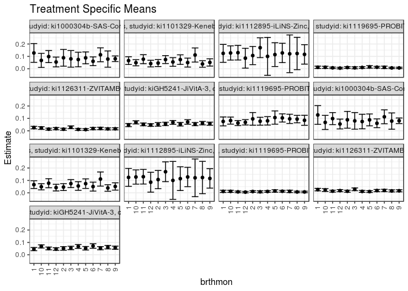

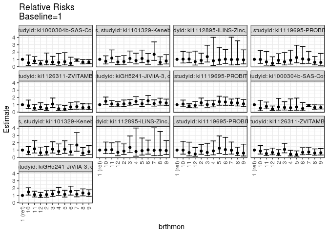

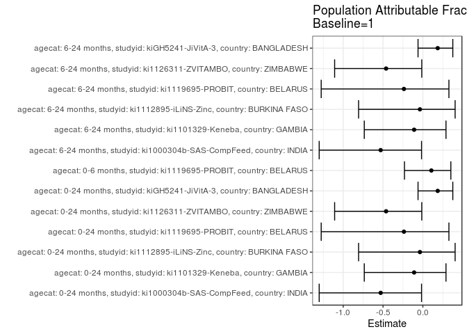

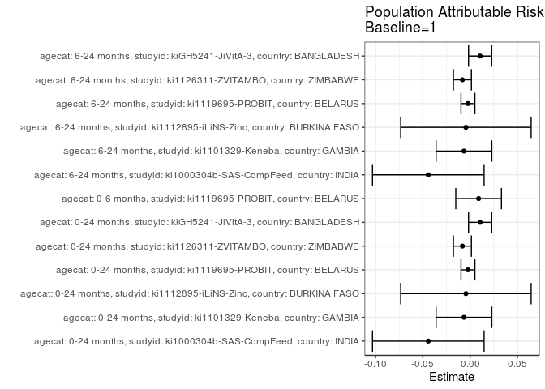

## Results Table

### Parameter: TSM

| agecat | studyid | country | intervention_level | baseline_level | estimate | ci_lower | ci_upper |
| --- | --- | --- | --- | --- | --- | --- | --- |
| 0-24 months | ki1000304b-SAS-CompFeed | INDIA | 1 | NA | 0.1276596 | 0.0518982 | 0.2034209 |
| 0-24 months | ki1000304b-SAS-CompFeed | INDIA | 2 | NA | 0.0886076 | 0.0209423 | 0.1562729 |
| 0-24 months | ki1000304b-SAS-CompFeed | INDIA | 3 | NA | 0.0800000 | 0.0129668 | 0.1470332 |
| 0-24 months | ki1000304b-SAS-CompFeed | INDIA | 4 | NA | 0.0746269 | 0.0159259 | 0.1333278 |
| 0-24 months | ki1000304b-SAS-CompFeed | INDIA | 5 | NA | 0.0879121 | 0.0399586 | 0.1358655 |
| 0-24 months | ki1000304b-SAS-CompFeed | INDIA | 6 | NA | 0.0606061 | 0.0252223 | 0.0959898 |
| 0-24 months | ki1000304b-SAS-CompFeed | INDIA | 7 | NA | 0.1129032 | 0.0569096 | 0.1688969 |
| 0-24 months | ki1000304b-SAS-CompFeed | INDIA | 8 | NA | 0.0783133 | 0.0127024 | 0.1439241 |
| 0-24 months | ki1000304b-SAS-CompFeed | INDIA | 9 | NA | 0.0809249 | 0.0584622 | 0.1033875 |
| 0-24 months | ki1000304b-SAS-CompFeed | INDIA | 10 | NA | 0.0675676 | 0.0107438 | 0.1243913 |
| 0-24 months | ki1000304b-SAS-CompFeed | INDIA | 11 | NA | 0.0983607 | 0.0497335 | 0.1469878 |
| 0-24 months | ki1000304b-SAS-CompFeed | INDIA | 12 | NA | 0.0546875 | 0.0152003 | 0.0941747 |
| 0-24 months | ki1101329-Keneba | GAMBIA | 1 | NA | 0.0658436 | 0.0346547 | 0.0970326 |
| 0-24 months | ki1101329-Keneba | GAMBIA | 2 | NA | 0.0460830 | 0.0181811 | 0.0739848 |
| 0-24 months | ki1101329-Keneba | GAMBIA | 3 | NA | 0.0742188 | 0.0421023 | 0.1063352 |
| 0-24 months | ki1101329-Keneba | GAMBIA | 4 | NA | 0.0548780 | 0.0200156 | 0.0897405 |
| 0-24 months | ki1101329-Keneba | GAMBIA | 5 | NA | 0.0738636 | 0.0352151 | 0.1125122 |
| 0-24 months | ki1101329-Keneba | GAMBIA | 6 | NA | 0.0500000 | 0.0138906 | 0.0861094 |
| 0-24 months | ki1101329-Keneba | GAMBIA | 7 | NA | 0.1111111 | 0.0541542 | 0.1680680 |
| 0-24 months | ki1101329-Keneba | GAMBIA | 8 | NA | 0.0388350 | 0.0124465 | 0.0652234 |
| 0-24 months | ki1101329-Keneba | GAMBIA | 9 | NA | 0.0511628 | 0.0217056 | 0.0806199 |
| 0-24 months | ki1101329-Keneba | GAMBIA | 10 | NA | 0.0486111 | 0.0237691 | 0.0734532 |
| 0-24 months | ki1101329-Keneba | GAMBIA | 11 | NA | 0.0772947 | 0.0409067 | 0.1136827 |
| 0-24 months | ki1101329-Keneba | GAMBIA | 12 | NA | 0.0418605 | 0.0150852 | 0.0686358 |
| 0-24 months | ki1112895-iLiNS-Zinc | BURKINA FASO | 1 | NA | 0.1242604 | 0.0519852 | 0.1965355 |
| 0-24 months | ki1112895-iLiNS-Zinc | BURKINA FASO | 2 | NA | 0.1066667 | 0.0332501 | 0.1800833 |
| 0-24 months | ki1112895-iLiNS-Zinc | BURKINA FASO | 3 | NA | 0.1700000 | 0.0900929 | 0.2499071 |
| 0-24 months | ki1112895-iLiNS-Zinc | BURKINA FASO | 4 | NA | 0.1000000 | -0.0529678 | 0.2529678 |
| 0-24 months | ki1112895-iLiNS-Zinc | BURKINA FASO | 5 | NA | 0.1142857 | 0.0183912 | 0.2101802 |
| 0-24 months | ki1112895-iLiNS-Zinc | BURKINA FASO | 6 | NA | 0.1276596 | 0.0495349 | 0.2057843 |

[output cut: 126 more lines]

### Parameter: E(Y)

| agecat | studyid | country | intervention_level | baseline_level | estimate | ci_lower | ci_upper |
| --- | --- | --- | --- | --- | --- | --- | --- |
| 0-24 months | ki1000304b-SAS-CompFeed | INDIA | NA | NA | 0.0834553 | 0.0601989 | 0.1067118 |
| 0-24 months | ki1101329-Keneba | GAMBIA | NA | NA | 0.0593290 | 0.0499611 | 0.0686968 |
| 0-24 months | ki1112895-iLiNS-Zinc | BURKINA FASO | NA | NA | 0.1198322 | 0.0943748 | 0.1452897 |
| 0-24 months | ki1119695-PROBIT | BELARUS | NA | NA | 0.0095893 | 0.0052864 | 0.0138922 |
| 0-24 months | ki1126311-ZVITAMBO | ZIMBABWE | NA | NA | 0.0176341 | 0.0149910 | 0.0202771 |
| 0-24 months | kiGH5241-JiVitA-3 | BANGLADESH | NA | NA | 0.0568247 | 0.0527145 | 0.0609348 |
| 0-6 months | ki1119695-PROBIT | BELARUS | NA | NA | 0.0846069 | 0.0570929 | 0.1121208 |
| 6-24 months | ki1000304b-SAS-CompFeed | INDIA | NA | NA | 0.0834553 | 0.0601989 | 0.1067118 |
| 6-24 months | ki1101329-Keneba | GAMBIA | NA | NA | 0.0593290 | 0.0499611 | 0.0686968 |
| 6-24 months | ki1112895-iLiNS-Zinc | BURKINA FASO | NA | NA | 0.1198322 | 0.0943748 | 0.1452897 |
| 6-24 months | ki1119695-PROBIT | BELARUS | NA | NA | 0.0095893 | 0.0052864 | 0.0138922 |
| 6-24 months | ki1126311-ZVITAMBO | ZIMBABWE | NA | NA | 0.0176341 | 0.0149910 | 0.0202771 |
| 6-24 months | kiGH5241-JiVitA-3 | BANGLADESH | NA | NA | 0.0568247 | 0.0527145 | 0.0609348 |

### Parameter: RR

| agecat | studyid | country | intervention_level | baseline_level | estimate | ci_lower | ci_upper |
| --- | --- | --- | --- | --- | --- | --- | --- |
| 0-24 months | ki1000304b-SAS-CompFeed | INDIA | 1 | 1 | 1.0000000 | 1.0000000 | 1.0000000 |
| 0-24 months | ki1000304b-SAS-CompFeed | INDIA | 2 | 1 | 0.6940928 | 0.2580130 | 1.8672113 |
| 0-24 months | ki1000304b-SAS-CompFeed | INDIA | 3 | 1 | 0.6266667 | 0.2775058 | 1.4151457 |
| 0-24 months | ki1000304b-SAS-CompFeed | INDIA | 4 | 1 | 0.5845771 | 0.1897451 | 1.8009968 |
| 0-24 months | ki1000304b-SAS-CompFeed | INDIA | 5 | 1 | 0.6886447 | 0.2477755 | 1.9139564 |
| 0-24 months | ki1000304b-SAS-CompFeed | INDIA | 6 | 1 | 0.4747475 | 0.1735473 | 1.2986961 |
| 0-24 months | ki1000304b-SAS-CompFeed | INDIA | 7 | 1 | 0.8844086 | 0.7376488 | 1.0603672 |
| 0-24 months | ki1000304b-SAS-CompFeed | INDIA | 8 | 1 | 0.6134538 | 0.3805286 | 0.9889547 |
| 0-24 months | ki1000304b-SAS-CompFeed | INDIA | 9 | 1 | 0.6339114 | 0.4157629 | 0.9665212 |
| 0-24 months | ki1000304b-SAS-CompFeed | INDIA | 10 | 1 | 0.5292793 | 0.1749374 | 1.6013534 |
| 0-24 months | ki1000304b-SAS-CompFeed | INDIA | 11 | 1 | 0.7704918 | 0.4348151 | 1.3653105 |
| 0-24 months | ki1000304b-SAS-CompFeed | INDIA | 12 | 1 | 0.4283854 | 0.2233101 | 0.8217902 |
| 0-24 months | ki1101329-Keneba | GAMBIA | 1 | 1 | 1.0000000 | 1.0000000 | 1.0000000 |
| 0-24 months | ki1101329-Keneba | GAMBIA | 2 | 1 | 0.6998848 | 0.3244630 | 1.5096907 |
| 0-24 months | ki1101329-Keneba | GAMBIA | 3 | 1 | 1.1271973 | 0.5934230 | 2.1410926 |
| 0-24 months | ki1101329-Keneba | GAMBIA | 4 | 1 | 0.8334604 | 0.3773437 | 1.8409111 |
| 0-24 months | ki1101329-Keneba | GAMBIA | 5 | 1 | 1.1218040 | 0.5538484 | 2.2721815 |
| 0-24 months | ki1101329-Keneba | GAMBIA | 6 | 1 | 0.7593750 | 0.3201610 | 1.8011262 |
| 0-24 months | ki1101329-Keneba | GAMBIA | 7 | 1 | 1.6875000 | 0.8397003 | 3.3912769 |
| 0-24 months | ki1101329-Keneba | GAMBIA | 8 | 1 | 0.5898060 | 0.2576194 | 1.3503293 |
| 0-24 months | ki1101329-Keneba | GAMBIA | 9 | 1 | 0.7770349 | 0.3686769 | 1.6377027 |
| 0-24 months | ki1101329-Keneba | GAMBIA | 10 | 1 | 0.7382813 | 0.3677940 | 1.4819688 |
| 0-24 months | ki1101329-Keneba | GAMBIA | 11 | 1 | 1.1739130 | 0.6020056 | 2.2891348 |
| 0-24 months | ki1101329-Keneba | GAMBIA | 12 | 1 | 0.6357559 | 0.2868288 | 1.4091527 |
| 0-24 months | ki1112895-iLiNS-Zinc | BURKINA FASO | 1 | 1 | 1.0000000 | 1.0000000 | 1.0000000 |
| 0-24 months | ki1112895-iLiNS-Zinc | BURKINA FASO | 2 | 1 | 0.8584127 | 0.3999918 | 1.8422188 |
| 0-24 months | ki1112895-iLiNS-Zinc | BURKINA FASO | 3 | 1 | 1.3680952 | 0.6385273 | 2.9312524 |
| 0-24 months | ki1112895-iLiNS-Zinc | BURKINA FASO | 4 | 1 | 0.8047619 | 0.1612593 | 4.0161510 |
| 0-24 months | ki1112895-iLiNS-Zinc | BURKINA FASO | 5 | 1 | 0.9197279 | 0.3190452 | 2.6513469 |
| 0-24 months | ki1112895-iLiNS-Zinc | BURKINA FASO | 6 | 1 | 1.0273556 | 0.4471675 | 2.3603226 |

[output cut: 126 more lines]

### Parameter: PAR

| agecat | studyid | country | intervention_level | baseline_level | estimate | ci_lower | ci_upper |
| --- | --- | --- | --- | --- | --- | --- | --- |
| 0-24 months | ki1000304b-SAS-CompFeed | INDIA | 1 | NA | -0.0442042 | -0.1031855 | 0.0147770 |
| 0-24 months | ki1101329-Keneba | GAMBIA | 1 | NA | -0.0065147 | -0.0359607 | 0.0229314 |
| 0-24 months | ki1112895-iLiNS-Zinc | BURKINA FASO | 1 | NA | -0.0044281 | -0.0733800 | 0.0645237 |
| 0-24 months | ki1119695-PROBIT | BELARUS | 1 | NA | -0.0022801 | -0.0096241 | 0.0050638 |
| 0-24 months | ki1126311-ZVITAMBO | ZIMBABWE | 1 | NA | -0.0081446 | -0.0176508 | 0.0013615 |
| 0-24 months | kiGH5241-JiVitA-3 | BANGLADESH | 1 | NA | 0.0105864 | -0.0016576 | 0.0228304 |
| 0-6 months | ki1119695-PROBIT | BELARUS | 1 | NA | 0.0089971 | -0.0151401 | 0.0331343 |
| 6-24 months | ki1000304b-SAS-CompFeed | INDIA | 1 | NA | -0.0442042 | -0.1031855 | 0.0147770 |
| 6-24 months | ki1101329-Keneba | GAMBIA | 1 | NA | -0.0065147 | -0.0359607 | 0.0229314 |
| 6-24 months | ki1112895-iLiNS-Zinc | BURKINA FASO | 1 | NA | -0.0044281 | -0.0733800 | 0.0645237 |
| 6-24 months | ki1119695-PROBIT | BELARUS | 1 | NA | -0.0022801 | -0.0096241 | 0.0050638 |
| 6-24 months | ki1126311-ZVITAMBO | ZIMBABWE | 1 | NA | -0.0081446 | -0.0176508 | 0.0013615 |
| 6-24 months | kiGH5241-JiVitA-3 | BANGLADESH | 1 | NA | 0.0105864 | -0.0016576 | 0.0228304 |

### Parameter: PAF

| agecat | studyid | country | intervention_level | baseline_level | estimate | ci_lower | ci_upper |
| --- | --- | --- | --- | --- | --- | --- | --- |
| 0-24 months | ki1000304b-SAS-CompFeed | INDIA | 1 | NA | -0.5296753 | -1.3014705 | -0.0167006 |
| 0-24 months | ki1101329-Keneba | GAMBIA | 1 | NA | -0.1098056 | -0.7352683 | 0.2902144 |
| 0-24 months | ki1112895-iLiNS-Zinc | BURKINA FASO | 1 | NA | -0.0369526 | -0.8069159 | 0.4049138 |
| 0-24 months | ki1119695-PROBIT | BELARUS | 1 | NA | -0.2377806 | -1.2762681 | 0.3269243 |
| 0-24 months | ki1126311-ZVITAMBO | ZIMBABWE | 1 | NA | -0.4618690 | -1.1076689 | -0.0139452 |
| 0-24 months | kiGH5241-JiVitA-3 | BANGLADESH | 1 | NA | 0.1862996 | -0.0607096 | 0.3757873 |
| 0-6 months | ki1119695-PROBIT | BELARUS | 1 | NA | 0.1063402 | -0.2308522 | 0.3511586 |
| 6-24 months | ki1000304b-SAS-CompFeed | INDIA | 1 | NA | -0.5296753 | -1.3014705 | -0.0167006 |
| 6-24 months | ki1101329-Keneba | GAMBIA | 1 | NA | -0.1098056 | -0.7352683 | 0.2902144 |
| 6-24 months | ki1112895-iLiNS-Zinc | BURKINA FASO | 1 | NA | -0.0369526 | -0.8069159 | 0.4049138 |
| 6-24 months | ki1119695-PROBIT | BELARUS | 1 | NA | -0.2377806 | -1.2762681 | 0.3269243 |
| 6-24 months | ki1126311-ZVITAMBO | ZIMBABWE | 1 | NA | -0.4618690 | -1.1076689 | -0.0139452 |
| 6-24 months | kiGH5241-JiVitA-3 | BANGLADESH | 1 | NA | 0.1862996 | -0.0607096 | 0.3757873 |